#### Data-Science-Pipeline

# Feature-Selection am Beispiel des Datensatzes "20 Newsgroups"

#### Christoph Gietl

#### 14. Juni 2021

# Datensatz und Ziel der Modellierung

## Hintergrund des Datensatzes: Usenet

- historischer Internet-Dienst (neben World-Wide-Web, E-Mail und anderen Diensten)
- unterteilt in zahlreiche Diskussionsforen (sogenannte Newsgroups)
- Nachrichtenformat ähnlich zu E-Mail
  - Kopfzeilen
  - Signaturen
  - Zitate

## Datenquelle und Datenformat

```python
ng20 = sklearn.datasets.fetch_20newsgroups(
    # Der Datensatz wurde bereits in Subsets "train" und "test" unterteilt.
    # Lade den gesamten Datensatz:
    subset="all",

    # Wir unterteilen den Datensatz später selbst.
    # Mische den Datensatz gut durch:
    random_state=42,
    shuffle=True,

    # Entferne Kopfzeilen, Signaturen und Zitate,
    # um die Zuordnung von Nachrichten zu Personen zu erschweren:
    remove=['headers', 'footers', 'quotes']
)
type(ng20.data), type(ng20.target), type(ng20.target_names)
```

```
(list, numpy.ndarray, list)
```

```python
len(ng20.data), len(ng20.target), len(ng20.target_names)
```

```
(18846, 18846, 20)
```

### Input-Daten

```python
types = set(type(item) for item in ng20.data)
types
```

```
{str}
```

```python
lengths = [len(item) for item in ng20.data]
min(lengths), max(lengths)
```

```
(0, 158791)
```

```python
numpy.mean(lengths).round(1), numpy.std(lengths).round(1)
```

```
(1169.7, 3858.6)
```

### Output-Daten (Zielvariable)

```python
numpy.unique(ng20.target, return_counts=True)
```

```
(array([ 0,  1,  2,  3,  4,  5,  6,  7,  8,  9, 10, 11, 12, 13, 14, 15, 16,
        17, 18, 19]),
 array([799, 973, 985, 982, 963, 988, 975, 990, 996, 994, 999, 991, 984,
        990, 987, 997, 910, 940, 775, 628]))
```

```python
print(ng20.target_names)
```

[output not shown]

### Input- und Output-Daten einer Beispielnachricht

```python
print(ng20.data[4_328][:434])
```

```
Not when your talking about cryptography.


Think again.  You won't see me using apple's new signature from the
finder feature.


This analogy fails in its assumption that the government gives two
squirts about credibility.


In addition, Apple's proclaimed purpose in releasing the Macintosh wasn't
survellience.

Quite the opposite:
"On January 24, Apple will introduce.... Macintosh, and you'll see why
1984 won't be, like '1984'"
```

```python
ng20.target[4_328], ng20.target_names[ng20.target[4_328]]
```

```
(11, 'sci.crypt')
```

## Ziel der Modellierung: Thematischer Textklassifikator

- nimmt Texte entgegen
- ordnet sie jeweils einem der 20 Themen zu (entsprechend den 20 Newsgroups)

# Naive Datenmodellierung

## Datenvorbereitung: Aufteilung in Trainings- und Testdaten

```python
X_train, X_test, y_train, y_test = sklearn.model_selection.train_test_split(
    ng20.data,
    ng20.target,
    random_state=42,
    stratify=ng20.target,
    test_size=2_000
)
numpy.unique(y_train, return_counts=True)
```

```
(array([ 0,  1,  2,  3,  4,  5,  6,  7,  8,  9, 10, 11, 12, 13, 14, 15, 16,
        17, 18, 19]),
 array([714, 870, 880, 878, 861, 883, 872, 885, 890, 889, 893, 886, 880,
        885, 882, 891, 813, 840, 693, 561]))
```

```python
numpy.unique(y_test, return_counts=True)
```

```
(array([ 0,  1,  2,  3,  4,  5,  6,  7,  8,  9, 10, 11, 12, 13, 14, 15, 16,
        17, 18, 19]),
 array([ 85, 103, 105, 104, 102, 105, 103, 105, 106, 105, 106, 105, 104,
        105, 105, 106,  97, 100,  82,  67]))
```

## Feature-Extraction und Modellanpassung

```python
xtrct = sklearn.feature_extraction.text.TfidfVectorizer(
    stop_words="english"
)
clssf_nb = sklearn.naive_bayes.ComplementNB()
ppln = sklearn.pipeline.Pipeline([
    ("xtrct", xtrct),
    ("clssf", clssf_nb)
])
```

```python
def cross_validate_and_fit(estimator, param_grid):
    gscv = sklearn.model_selection.GridSearchCV(
        estimator=estimator,
        n_jobs=3,
        param_grid=param_grid,
        return_train_score=True,
        scoring="roc_auc_ovr_weighted",
        verbose=9
    )
    gscv.fit(X_train, y_train)
    print()

    res = gscv.cv_results_
    print(f"Parameters:       {res['params']}")
    print(f"Mean train score: {res['mean_train_score'].round(3)}")
    print(f"Mean test score:  {res['mean_test_score'].round(3)}")

    return gscv


tuned_ppln = cross_validate_and_fit(
    estimator=ppln,
    param_grid={'clssf__alpha': [0.01, 0.03, 0.1, 0.3, 1.0]}
)
```

```
Fitting 5 folds for each of 5 candidates, totalling 25 fits

Parameters:       [{'clssf__alpha': 0.01}, {'clssf__alpha': 0.03}, {'clssf__alpha': 0.1}, {'clssf__alpha': 0.3}, {'clssf__alpha': 1.0}]
Mean train score: [0.998 0.997 0.997 0.995 0.993]
Mean test score:  [0.973 0.975 0.977 0.976 0.974]
```

## Modellanalyse

### Features

```python
feature_names = tuned_ppln.best_estimator_.named_steps["xtrct"].get_feature_names()
len(feature_names)
```

```
127345
```

```python
def print_sorted_samples(lst):
    rng = numpy.random.default_rng(seed=42)
    samples = rng.choice(lst, replace=False, size=100)
    samples.sort()
    print(samples)


print_sorted_samples(feature_names)
```

```
['2024' '3388' '3999' '417' '4tq1jv' '5286' '578' '5e8g4' '5pv'
 '83jx0dadf' '87___________________' '93109' '_cheap_' '_rqpp4db' 'a4gc0'
 'ak' 'anafranil' 'ap8h' 'arromdian' 'bench' 'benes' 'booktitle'
 'circumstantial' 'comparitive' 'cyberspace' 'delia' 'despised' 'dxsx'
 'eighth' 'ellison' 'endlessly' 'endprocedure' 'f0j' 'fjpbkbpu' 'frame'
 'glucoma' 'goofy' 'grad' 'gravis' 'gukasian' 'gyv' 'hallandale'
 'hallucinating' 'hippi' 'homelessness' 'howell' 'hyqe' 'institutional'
 'interplanetary' 'janney' 'k2mv5805t' 'kzm' 'l4y4j2' 'leedom' 'lmrcr1o'
 'mtm' 'multipath' 'myopia' 'nb6c' 'noble' 'oi_w_' 'orthogonal'
 'overwhelming' 'owen' 'p90t' 'pendelum' 'petah' 'petcock' 'ppw' 'q6p1i'
 'quiet' 'qwt' 'redneck' 'regent' 'reincarnated' 'restrains' 'ripem'
 'roelle' 'rq9' 'rythm' 'scatter' 'serials' 'sng' 'spaceward' 'sq9wmgk'
 'squalid' 'stg' 'strategic' 't5k1' 't5m19' 'trp' 'tyrant' 'ug3'
 'uniformed' 'vdu' 'victimized' 'walkie' 'xhm' 'xoutput_info'
 'xtungrabpointer']
```

### Koeffizienten der Features

```python
coefficients = tuned_ppln.best_estimator_.named_steps["clssf"].feature_log_prob_
coefficients.shape
```

```
(20, 127345)
```

```python
numpy.prod(coefficients.shape), (coefficients==0).any()
```

```
(2546900, False)
```

# Feature-Selection

## Motivation

- entferne unnütze Features
- Ziel: sparmsames Modell
  - schnellere Vorhersagen
  - bei gleicher (oder nur geringfügig schlechterer) Vorhersagequalität
- möglicher Nachteil: höhere Trainingszeit

### Spielzeug-Beispiel

```python
X, y = sklearn.datasets.load_diabetes(return_X_y=True)
X.shape, y.shape
```

```
((442, 10), (442,))
```

```python
rgr = sklearn.linear_model.LinearRegression()
rgr_cv = sklearn.model_selection.GridSearchCV(rgr, param_grid={}, return_train_score=True)
rgr_cv.fit(X,y)
rgr_cv.cv_results_
```

```
{'mean_fit_time': array([0.001015]),
 'std_fit_time': array([0.0004325]),
 'mean_score_time': array([0.00039339]),
 'std_score_time': array([4.49146687e-05]),
 'params': [{}],
 'split0_test_score': array([0.42955643]),
 'split1_test_score': array([0.52259828]),
 'split2_test_score': array([0.4826784]),
 'split3_test_score': array([0.42650827]),
 'split4_test_score': array([0.55024923]),
 'mean_test_score': array([0.48231812]),
 'std_test_score': array([0.0492662]),
 'rank_test_score': array([1], dtype=int32),
 'split0_train_score': array([0.52428374]),
 'split1_train_score': array([0.51032284]),
 'split2_train_score': array([0.52379623]),
 'split3_train_score': array([0.53137699]),
 'split4_train_score': array([0.50775176]),
 'mean_train_score': array([0.51950631]),
 'std_train_score': array([0.00899606])}
```

```python
rgr_cv.cv_results_["mean_train_score"].round(3), rgr_cv.cv_results_["mean_test_score"].round(3)
```

```
(array([0.52]), array([0.482]))
```

## Filter-Methoden

- Idee: entferne Features vorab, die voraussichtlich nicht nützlich sein werden
- Beispiel:
  - Berechne für jedes Feature die Korrelation mit der Zielvariablen.
  - Entferne alle Features, deren Korrelationswert unterhalb einer bestimmten Schwelle liegt.
- Vorteil: schnelle Berechnung
- Nachteil:
  - keine Berücksichtigung des Modells
  - mögliche Entfernung von Features, die für das Modell wichtig sind
- Empfehlung:
  - vorsichtig verwenden
  - nicht zu viele Features entfernen

### Beispiel für Filter-Methoden

```python
fltr_rgr = sklearn.pipeline.Pipeline([
    ("slct", sklearn.feature_selection.SelectKBest(k=4, score_func=sklearn.feature_selection.mutual_info_regression)),
    ("rgr", sklearn.linear_model.LinearRegression())
])
fltr_rgr_cv = sklearn.model_selection.GridSearchCV(fltr_rgr, param_grid={}, return_train_score=True)
fltr_rgr_cv.fit(X,y)
fltr_rgr_cv.cv_results_
```

```
{'mean_fit_time': array([0.02410145]),
 'std_fit_time': array([0.00122735]),
 'mean_score_time': array([0.0005228]),
 'std_score_time': array([6.18681099e-05]),
 'params': [{}],
 'split0_test_score': array([0.37557259]),
 'split1_test_score': array([0.48557479]),
 'split2_test_score': array([0.49588666]),
 'split3_test_score': array([0.39610646]),
 'split4_test_score': array([0.48743854]),
 'mean_test_score': array([0.44811581]),
 'std_test_score': array([0.05137898]),
 'rank_test_score': array([1], dtype=int32),
 'split0_train_score': array([0.48157035]),
 'split1_train_score': array([0.47640634]),
 'split2_train_score': array([0.46458324]),
 'split3_train_score': array([0.4870041]),
 'split4_train_score': array([0.45537312]),
 'mean_train_score': array([0.47298743]),
 'std_train_score': array([0.01151275])}
```

```python
fltr_rgr_cv.cv_results_["mean_train_score"].round(3), fltr_rgr_cv.cv_results_["mean_test_score"].round(3)
```

```
(array([0.473]), array([0.448]))
```

```python
bool_support = fltr_rgr_cv.best_estimator_.named_steps["slct"].get_support()
support = [idx for idx in range(len(bool_support)) if bool_support[idx]]
support
```

```
[2, 7, 8, 9]
```

## Wrapper-Methoden

- Idee:
  - Passe Modell auf einer Teilmenge der Features an.
  - Bewerte die Modellqualität.
  - Verbessere die Teilmenge der Features iterativ.
- Vorteil:
  - Features, die nur in Kombination nützlich sind, können beibehalten werden.
- Nachteil:
  - teure Berechnung

### Beispiele für Wrapper-Methoden

#### Forward

```python
slct_fwd = sklearn.feature_selection.SequentialFeatureSelector(
    sklearn.linear_model.LinearRegression(),
    direction="forward",
    n_features_to_select=4
)
wrpr_rgr = sklearn.pipeline.Pipeline([
    ("slct", slct_fwd),
    ("rgr", sklearn.linear_model.LinearRegression())
])
tuned_wrpr_rgr = sklearn.model_selection.GridSearchCV(wrpr_rgr, param_grid={}, return_train_score=True)
tuned_wrpr_rgr.fit(X,y)
tuned_wrpr_rgr.cv_results_
```

```
{'mean_fit_time': array([0.21078701]),
 'std_fit_time': array([0.01338347]),
 'mean_score_time': array([0.00057898]),
 'std_score_time': array([0.00028657]),
 'params': [{}],
 'split0_test_score': array([0.37782954]),
 'split1_test_score': array([0.49784408]),
 'split2_test_score': array([0.46023915]),
 'split3_test_score': array([0.40836977]),
 'split4_test_score': array([0.53003558]),
 'mean_test_score': array([0.45486362]),
 'std_test_score': array([0.05589806]),
 'rank_test_score': array([1], dtype=int32),
 'split0_train_score': array([0.50470573]),
 'split1_train_score': array([0.48662052]),
 'split2_train_score': array([0.49184417]),
 'split3_train_score': array([0.50700358]),
 'split4_train_score': array([0.48095316]),
 'mean_train_score': array([0.49422543]),
 'std_train_score': array([0.01012695])}
```

```python
tuned_wrpr_rgr.cv_results_["mean_train_score"].round(3), tuned_wrpr_rgr.cv_results_["mean_test_score"].round(3)
```

```
(array([0.494]), array([0.455]))
```

```python
bool_support = tuned_wrpr_rgr.best_estimator_.named_steps["slct"].get_support()
support = [idx for idx in range(len(bool_support)) if bool_support[idx]]
support
```

```
[2, 3, 6, 8]
```

#### Backward

```python
slct_bwd = sklearn.feature_selection.SequentialFeatureSelector(
    sklearn.linear_model.LinearRegression(),
    direction="backward",
    n_features_to_select=4
)
wrpr_rgr = sklearn.pipeline.Pipeline([
    ("slct", slct_bwd),
    ("rgr", sklearn.linear_model.LinearRegression())
])
tuned_wrpr_rgr = sklearn.model_selection.GridSearchCV(wrpr_rgr, param_grid={}, return_train_score=True)
tuned_wrpr_rgr.fit(X,y)
tuned_wrpr_rgr.cv_results_
```

```
{'mean_fit_time': array([0.29991817]),
 'std_fit_time': array([0.01889886]),
 'mean_score_time': array([0.00052462]),
 'std_score_time': array([0.00017981]),
 'params': [{}],
 'split0_test_score': array([0.42356667]),
 'split1_test_score': array([0.49784408]),
 'split2_test_score': array([0.46023915]),
 'split3_test_score': array([0.40836977]),
 'split4_test_score': array([0.53003558]),
 'mean_test_score': array([0.46401105]),
 'std_test_score': array([0.04527657]),
 'rank_test_score': array([1], dtype=int32),
 'split0_train_score': array([0.49651582]),
 'split1_train_score': array([0.48662052]),
 'split2_train_score': array([0.49184417]),
 'split3_train_score': array([0.50700358]),
 'split4_train_score': array([0.48095316]),
 'mean_train_score': array([0.49258745]),
 'std_train_score': array([0.00888561])}
```

```python
tuned_wrpr_rgr.cv_results_["mean_train_score"].round(3), tuned_wrpr_rgr.cv_results_["mean_test_score"].round(3)
```

```
(array([0.493]), array([0.464]))
```

```python
bool_support = tuned_wrpr_rgr.best_estimator_.named_steps["slct"].get_support()
support = [idx for idx in range(len(bool_support)) if bool_support[idx]]
support
```

```
[2, 3, 4, 8]
```

## Embedded-Methoden

- Idee: Modell trifft während des Trainings eine Auswahl der Features.
- Beispiele:
  - Entscheidungsbäume
  - lineare Modelle mit L1-Regularisierung
- Vorteil:
  - schnelle Berechnung
  - Auswahl von Features, die für das Modell nützlich sind
- Nachteil:
  - weniger mächtig als Wrapper-Methoden

### Beispiele für Embedded-Methoden

```python
tuned_embedded_rgr = sklearn.model_selection.GridSearchCV(
    sklearn.linear_model.Lasso(normalize=True),
    param_grid={"alpha": [0.3]},
    return_train_score=True
)
tuned_embedded_rgr.fit(X,y)
tuned_embedded_rgr.cv_results_
```

```
{'mean_fit_time': array([0.00107279]),
 'std_fit_time': array([0.00034344]),
 'mean_score_time': array([0.00038948]),
 'std_score_time': array([4.99316132e-05]),
 'param_alpha': masked_array(data=[0.3],
              mask=[False],
        fill_value='?',
             dtype=object),
 'params': [{'alpha': 0.3}],
 'split0_test_score': array([0.37792307]),
 'split1_test_score': array([0.48731802]),
 'split2_test_score': array([0.48070249]),
 'split3_test_score': array([0.45049619]),
 'split4_test_score': array([0.51318003]),
 'mean_test_score': array([0.46192396]),
 'std_test_score': array([0.04650036]),
 'rank_test_score': array([1], dtype=int32),
 'split0_train_score': array([0.49621581]),
 'split1_train_score': array([0.47664432]),
 'split2_train_score': array([0.48928877]),
 'split3_train_score': array([0.48948488]),
 'split4_train_score': array([0.47353178]),
 'mean_train_score': array([0.48503311]),
 'std_train_score': array([0.00855142])}
```

```python
tuned_embedded_rgr.cv_results_["mean_train_score"].round(3), tuned_embedded_rgr.cv_results_["mean_test_score"].round(3)
```

```
(array([0.485]), array([0.462]))
```

```python
bool_support = (tuned_embedded_rgr.best_estimator_.coef_!=0)
support = [idx for idx in range(len(bool_support)) if bool_support[idx]]
support
```

```
[2, 3, 6, 8]
```

#### RFE

```python
slct_rfe = sklearn.feature_selection.RFE(
    sklearn.linear_model.LinearRegression(),
    n_features_to_select=4
)
rfe_rgr = sklearn.pipeline.Pipeline([
    ("slct", slct_rfe),
    ("rgr", sklearn.linear_model.LinearRegression())
])
tuned_rfe_rgr = sklearn.model_selection.GridSearchCV(rfe_rgr, param_grid={}, return_train_score=True)
tuned_rfe_rgr.fit(X,y)
tuned_rfe_rgr.cv_results_
```

```
{'mean_fit_time': array([0.0058229]),
 'std_fit_time': array([0.00060504]),
 'mean_score_time': array([0.00046597]),
 'std_score_time': array([3.63312992e-05]),
 'params': [{}],
 'split0_test_score': array([0.38333569]),
 'split1_test_score': array([0.50553064]),
 'split2_test_score': array([0.49985887]),
 'split3_test_score': array([0.37537075]),
 'split4_test_score': array([0.50505252]),
 'mean_test_score': array([0.4538297]),
 'std_test_score': array([0.06089444]),
 'rank_test_score': array([1], dtype=int32),
 'split0_train_score': array([0.48487474]),
 'split1_train_score': array([0.46480069]),
 'split2_train_score': array([0.46974272]),
 'split3_train_score': array([0.49512594]),
 'split4_train_score': array([0.46820776]),
 'mean_train_score': array([0.47655037]),
 'std_train_score': array([0.01156153])}
```

```python
tuned_rfe_rgr.cv_results_["mean_train_score"].round(3), tuned_rfe_rgr.cv_results_["mean_test_score"].round(3)
```

```
(array([0.477]), array([0.454]))
```

```python
bool_support = tuned_rfe_rgr.best_estimator_.named_steps["slct"].get_support()
support = [idx for idx in range(len(bool_support)) if bool_support[idx]]
support
```

```
[2, 4, 5, 8]
```

# Verbesserte Modellierung

## Filter-Methoden

```python
slct_kbest_chi2 = sklearn.feature_selection.SelectKBest(
    score_func=sklearn.feature_selection.chi2
)
ppln_fltr = sklearn.pipeline.Pipeline([
    ("xtrct", xtrct),
    ("slct", slct_kbest_chi2),
    ("clssf", clssf_nb)
])
tuned_ppln_fltr = cross_validate_and_fit(
    estimator=ppln_fltr,
    param_grid={
        "slct__k": [100, 300, 1_000, 3_000, 10_000, 30_000, "all"],
        "clssf__alpha": [0.1]
    }
)
```

```
Fitting 5 folds for each of 7 candidates, totalling 35 fits

Parameters:       [{'clssf__alpha': 0.1, 'slct__k': 100}, {'clssf__alpha': 0.1, 'slct__k': 300}, {'clssf__alpha': 0.1, 'slct__k': 1000}, {'clssf__alpha': 0.1, 'slct__k': 3000}, {'clssf__alpha': 0.1, 'slct__k': 10000}, {'clssf__alpha': 0.1, 'slct__k': 30000}, {'clssf__alpha': 0.1, 'slct__k': 'all'}]
Mean train score: [0.865 0.924 0.96  0.978 0.991 0.996 0.997]
Mean test score:  [0.861 0.918 0.95  0.965 0.973 0.976 0.977]
```

## Wrapper-Methoden

- entfallen, da rechnerisch zu aufwendig

## Embedded-Methoden

### Logistische Regression mit L1-Regularisierung

```python
clssf_lr = sklearn.linear_model.LogisticRegression(
    penalty="l1",
    random_state=42,
    solver="liblinear"
)
ppln_embd_lr = sklearn.pipeline.Pipeline([
    ("xtrct", xtrct),
    ("clssf", clssf_lr)
])
tuned_ppln_embd_lr = cross_validate_and_fit(
    estimator = ppln_embd_lr,
    param_grid={"clssf__C": [0.6]}
)
```

```
Fitting 5 folds for each of 1 candidates, totalling 5 fits

Parameters:       [{'clssf__C': 0.6}]
Mean train score: [0.951]
Mean test score:  [0.937]
```

```python
coefficients = tuned_ppln_embd_lr.best_estimator_.named_steps["clssf"].coef_
coefficients.shape
```

```
(20, 127345)
```

```python
feature_has_non_zero_coefficient = (coefficients!=0).any(axis=0)
feature_has_non_zero_coefficient.sum()
```

```
1113
```

### Logistische Regression mit L1-Regularisierung und anschließendem Naive-Bayes

```python
slct_mdl_lr = sklearn.feature_selection.SelectFromModel(
    estimator=clssf_lr
)
ppln_embd_lr_nb = sklearn.pipeline.Pipeline([
    ("xtrct", xtrct),
    ("slct", slct_mdl_lr),
    ("clssf", clssf_nb)
])
tuned_ppln_embd_lr_nb = cross_validate_and_fit(
    estimator=ppln_embd_lr_nb,
    param_grid={
        "slct__estimator__C": [0.6],
        "clssf__alpha": [0.1]
    }
)
```

```
Fitting 5 folds for each of 1 candidates, totalling 5 fits

Parameters:       [{'clssf__alpha': 0.1, 'slct__estimator__C': 0.6}]
Mean train score: [0.963]
Mean test score:  [0.951]
```

```python
tuned_ppln_embd_lr_nb.best_estimator_.named_steps["slct"].get_support().sum()
```

```
1113
```

### RFE-SVC mit anschließendem Naive-Bayes

```python
slct_rfe_svc = sklearn.feature_selection.RFE(
    estimator=sklearn.svm.LinearSVC(random_state=42),
    n_features_to_select=1_000,
    step=10_000
)
ppln_embd_rfe = sklearn.pipeline.Pipeline([
    ("xtrct", xtrct),
    ("slct", slct_rfe_svc),
    ("clssf", clssf_nb)
])
tuned_ppln_embd_rfe = cross_validate_and_fit(
    estimator=ppln_embd_rfe,
    param_grid={
        "slct__estimator__C": [0.03, 0.1, 0.3, 1.0],
        "clssf__alpha": [0.1]
    }
)
```

```
Fitting 5 folds for each of 4 candidates, totalling 20 fits

Parameters:       [{'clssf__alpha': 0.1, 'slct__estimator__C': 0.03}, {'clssf__alpha': 0.1, 'slct__estimator__C': 0.1}, {'clssf__alpha': 0.1, 'slct__estimator__C': 0.3}, {'clssf__alpha': 0.1, 'slct__estimator__C': 1.0}]
Mean train score: [0.961 0.964 0.966 0.966]
Mean test score:  [0.951 0.952 0.953 0.95 ]
```

## Extrahiere selektierte Features

```python
feature_names = tuned_ppln_embd_rfe.best_estimator_.named_steps["xtrct"].get_feature_names()
```

```python
selected = tuned_ppln_embd_rfe.best_estimator_.named_steps["slct"].get_support()
numpy.unique(selected, return_counts=True)
```

```
(array([False,  True]), array([126345,   1000]))
```

```python
selected_features = [
    feature
    for idx, feature in enumerate(feature_names)
    if selected[idx]
]
print_sorted_samples(selected_features)
```

```
['american' 'asking' 'atf' 'average' 'baseball' 'batteries' 'belief' 'bit'
 'bullets' 'camera' 'cci' 'cheap' 'christ' 'christianity' 'cleveland'
 'colour' 'com' 'commercial' 'cramer' 'current' 'denning' 'dod'
 'electronics' 'excellent' 'faith' 'feustel' 'following' 'formats'
 'freedom' 'game' 'gas' 'gopher' 'hardware' 'hear' 'help' 'hst' 'humans'
 'icon' 'ideas' 'images' 'impulse' 'interstellar' 'islamic' 'istanbul'
 'jerusalem' 'jewish' 'josh' 'jupiter' 'key' 'lens' 'lock' 'lunar' 'med'
 'mouse' 'mr' 'msg' 'obo' 'original' 'output' 'palestinians' 'pds' 'peace'
 'perfect' 'pick' 'piece' 'pitching' 'plus' 'points' 'politics' 'prevent'
 'printer' 'private' 'problems' 'product' 'rangers' 'right' 'rkba'
 'rotation' 'round' 'running' 'runs' 'secret' 'selling' 'sharks' 'sho'
 'sin' 'slot' 'sox' 'sports' 'survivors' 'taxes' 'tech' 'temperature'
 'truth' 'turks' 'users' 'w4wg' 'western' 'wfw' 'works']
```

## Vereinfache Vectorizer

```python
xtrct_vcb = sklearn.feature_extraction.text.TfidfVectorizer(
    vocabulary=selected_features
)
smpl_ppln = sklearn.pipeline.Pipeline([
    ("xtrct", xtrct_vcb),
    ("clssf", clssf_nb)
])
tuned_smpl_ppln = cross_validate_and_fit(
    estimator=smpl_ppln,
    param_grid={"clssf__alpha": [0.003, 0.01, 0.03, 0.1, 0.3]}
)
```

```
Fitting 5 folds for each of 5 candidates, totalling 25 fits

Parameters:       [{'clssf__alpha': 0.003}, {'clssf__alpha': 0.01}, {'clssf__alpha': 0.03}, {'clssf__alpha': 0.1}, {'clssf__alpha': 0.3}]
Mean train score: [0.97 0.97 0.97 0.97 0.97]
Mean test score:  [0.962 0.962 0.962 0.962 0.962]
```

```python
tuned_smpl_ppln.score(X_test, y_test)
```

```
0.9566302795913874
```

## Plausibilitätscheck

```
<sklearn.metrics._plot.confusion_matrix.ConfusionMatrixDisplay at 0x125e9ba60>
```

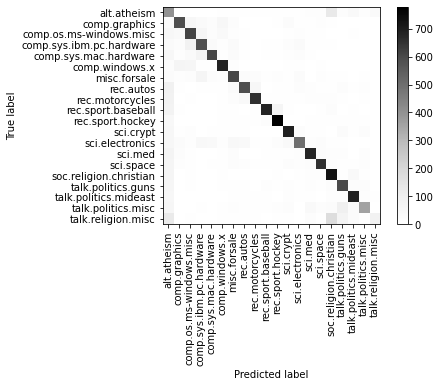

```python
sklearn.metrics.plot_confusion_matrix(
    tuned_smpl_ppln,
    X_train,
    y_train,
    cmap=matplotlib.pyplot.cm.Greys,
    display_labels=ng20.target_names,
    include_values=False,
    xticks_rotation="vertical"
)
```

### Erkläre falsche Atheisten

```python
y_train_pred = tuned_smpl_ppln.predict(X_train)
y_train_pred_proba = tuned_smpl_ppln.predict_proba(X_train)
```

```python
false_atheists = numpy.logical_and(y_train>0, y_train_pred==0)
false_atheist_idcs = numpy.where(false_atheists)[0]
false_atheist_idcs.shape
```

```
(1077,)
```

```python
false_atheist_probas=y_train_pred_proba[false_atheist_idcs,:]
false_atheist_probas.round(3)
```

```
array([[0.06 , 0.049, 0.048, ..., 0.052, 0.053, 0.055],
       [0.05 , 0.05 , 0.05 , ..., 0.05 , 0.05 , 0.05 ],
       [0.05 , 0.05 , 0.05 , ..., 0.05 , 0.05 , 0.05 ],
       ...,
       [0.05 , 0.05 , 0.05 , ..., 0.05 , 0.05 , 0.05 ],
       [0.094, 0.045, 0.045, ..., 0.061, 0.048, 0.054],
       [0.05 , 0.05 , 0.05 , ..., 0.05 , 0.05 , 0.05 ]])
```

```python
max_prob_per_sample = false_atheist_probas.max(axis=1)
min_prob_per_sample = false_atheist_probas.min(axis=1)
sample_has_constant_prob = \
    (min_prob_per_sample == max_prob_per_sample)
numpy.unique(sample_has_constant_prob, return_counts=True)
```

```
(array([False,  True]), array([213, 864]))
```

```python
false_atheists_with_const_prob = false_atheist_idcs[sample_has_constant_prob]
```

```python
print(X_train[false_atheists_with_const_prob[25]])
```

```
It was a test of the first reusable tool.


Pointy so they can find them or so they will stick into their pants better, and
be closer to their brains?
```

```python
print(X_train[false_atheists_with_const_prob[527]])
```

[output not shown]

```python
print(X_train[false_atheists_with_const_prob[773]])
```

```
   To you, it shouldn't matter if you do evil things or good things.  It is
   all meaningless in the end anyway.  So go rob a bank.  Go tell someone
   you dislike that he is a dirty rotten slime bag.  What's restraining you?
```

# Zusammenfassung und Ausblick

## Weiterführende Literatur

- A. Zheng, A. Casari: *Feature engineering for machine learning: principles and techniques for data scientists.* O'Reilly, 2018.
- I. Guyon, A. Elisseeff: "An introduction to variable and feature selection." *Journal of machine learning research* 3: 1157-1182.
- Y. Saeys, I. Inza, P. Larrañaga: "A review of feature selection techniques in bioinformatics." *Bioinformatics* 23: 2507-2517.